# 06- Modelos log-lineales

Teresa Ortiz

Veremos un ejemplo con los datos de Rienis (incluídos en gRim):

*Data collected at the beginning of a 15 year follow-up study of probable risk factors for coronary thrombosis. Data are from all men employed in a car factory.*

Variables:  
*A table with 6 discrete variables. A: smoking, B: strenous mental work, D: strenuous physical work, E: systolic blood pressure, F: ratio of lipoproteins, G: Family anamnesis of coronary heart disease.*

```r
library(gRim)
library(dplyr)
library(Rgraphviz)
data(reinis)
reinis_df <- data.frame(reinis)
head(reinis_df)
```

```
##   smoke mental phys systol protein family Freq
## 1     y      y    y      y       y      y   44
## 2     n      y    y      y       y      y   40
## 3     y      n    y      y       y      y  112
## 4     n      n    y      y       y      y   67
## 5     y      y    n      y       y      y  129
## 6     n      y    n      y       y      y  145
```

Comenzamos con modelo de independencia:

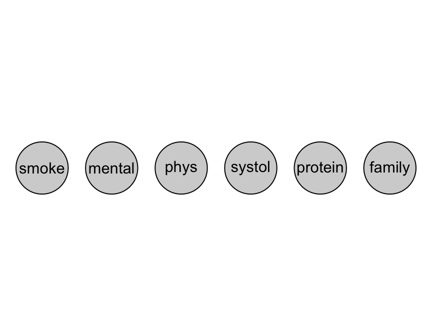

```r
m_init <- dmod(~.^1 , data = reinis)
plot(m_init)
```

¿Cómo vemos que este modelo no es apropiado? Obtenemos la conjunta no normalizada, que está en terminos de frecuencias ajustadas.

```r
m_init$fit$fit
```

```
## , , phys = y, systol = y, protein = y, family = y
##
##      mental
## smoke    y    n
##     y 79.2 57.9
##     n 72.5 53.1
##
## , , phys = n, systol = y, protein = y, family = y
##
##      mental
## smoke    y    n
##     y 78.1 57.1
##     n 71.5 52.3
##
## , , phys = y, systol = n, protein = y, family = y
##
##      mental
## smoke    y    n
##     y 59.1 43.3
##     n 54.1 39.6
##
## , , phys = n, systol = n, protein = y, family = y
##
##      mental
## smoke    y    n
##     y 58.3 42.7
##     n 53.4 39.1
##
## , , phys = y, systol = y, protein = n, family = y
##
##      mental
## smoke    y    n
##     y 58.2 42.6
##     n 53.3 39.0
##
## , , phys = n, systol = y, protein = n, family = y
##
##      mental
## smoke    y    n
##     y 57.4 42.0
```

[output cut: 56 more lines]

```
##     n  8.6  6.3
##
## , , phys = y, systol = n, protein = n, family = n
##
##      mental
## smoke    y    n
##     y  7.1  5.2
##     n  6.5  4.8
##
## , , phys = n, systol = n, protein = n, family = n
##
##      mental
## smoke    y    n
##     y  7.0  5.2
##     n  6.5  4.7
```

```r
ajuste_1 <- data.frame(m_init$fit$fit)
ajuste_1$Freq_ajustada <- ajuste_1$Freq
ajuste_1$Freq <- NULL
dat_1 <- left_join(reinis_df, ajuste_1)
```

Podemos calcular residuales de la siguiente forma:

```r
residuales <- (dat_1$Freq - dat_1$Freq_ajustada)/sqrt(dat_1$Freq_ajustada)
```

estos deben tener una distribución aproximada normal estándar pues el número de observaciones esperado en una celda de probabilidad p es Np, y su varianza es Np(1-p). Cuando p es chica, valor esperado y varianza son aproximadamente iguales. Cuando N es grande, adicionalmente, los conteos se distribuyen aproximadamente poisson con media grande, que se puede aproximar con una normal con media Freq_ajusta y desviación estándar raíz de Freq_ajustada.

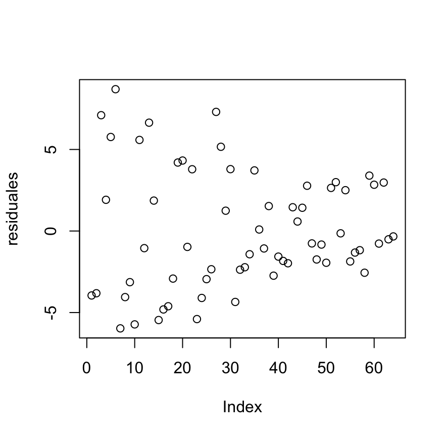

```r
plot(residuales)
```

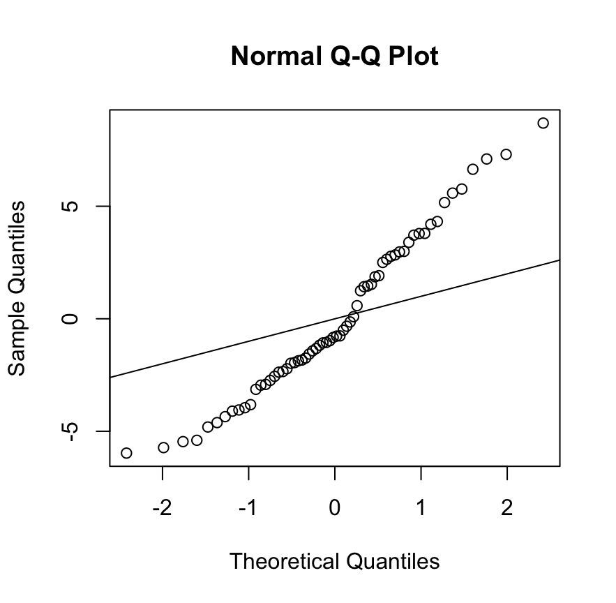

```r
qqnorm(residuales)
abline(a = 0, b = 1)
```

Y vemos que los residuales tienen dispersión demasiado grande. Usamos aic para ajustar un segundo modelo:

```r
m_reinis <- stepwise(m_init, criterion = 'aic', details = T,
                     direction = 'forward', type='unrestricted')
```

[output not shown]

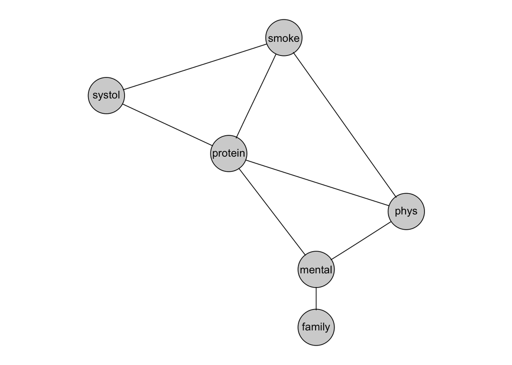

```r
plot(m_reinis)
```

```r
ajuste_1 <- data.frame(m_reinis$fit$fit)
ajuste_1$Freq_ajustada <- ajuste_1$Freq
ajuste_1$Freq <- NULL
dat_1 <- left_join(reinis_df, ajuste_1)
```

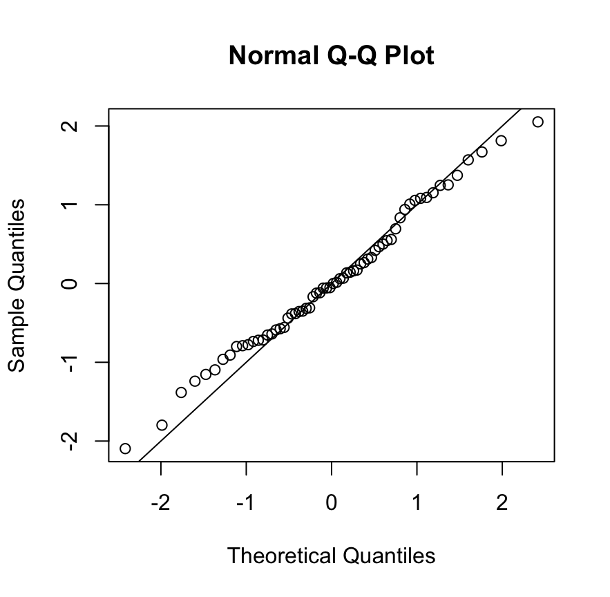

```r
residuales <- (dat_1$Freq - dat_1$Freq_ajustada)/sqrt(dat_1$Freq_ajustada)
qqnorm(residuales)
abline(a=0,b=1)
```

en este caso el ajuste es razonable.

También podemos checar cómo se desvían los observados de los ajustados dependiendo de las variables. Podemos empezar calculando algunas marginales.

Por ejemplo:

```r
library(tidyr)
```

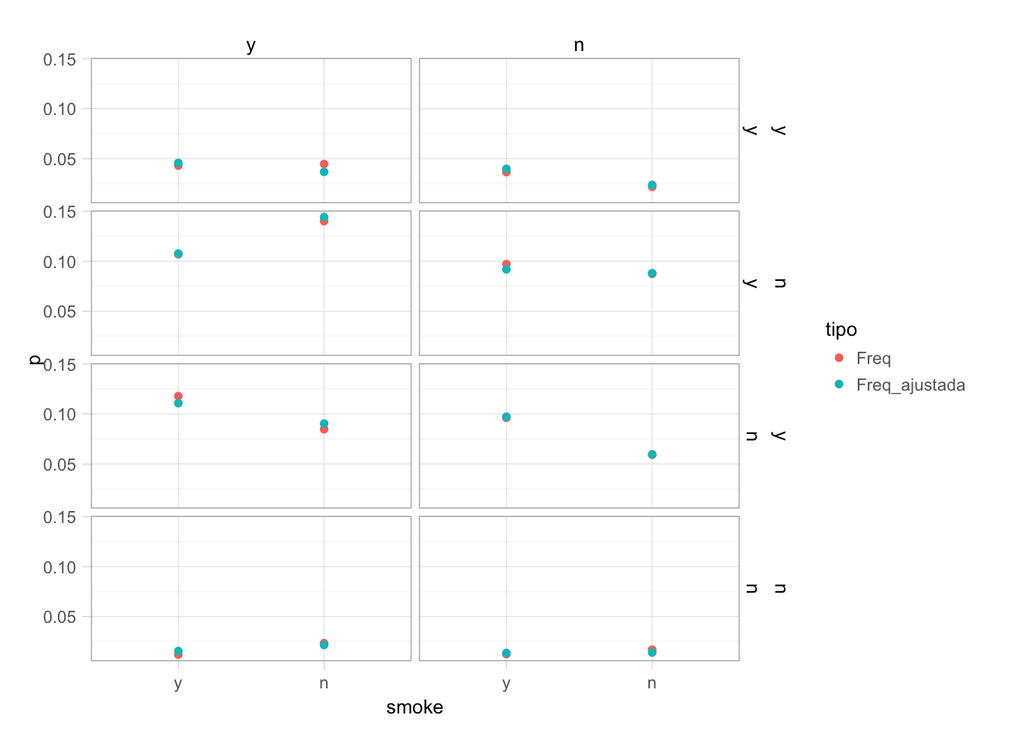

```r
library(ggplot2)

dat_2 <- dat_1 %>%
  group_by(smoke, mental, phys, systol) %>%
  summarise(
    Freq = sum(Freq),
    Freq_ajustada = sum(Freq_ajustada)
    ) %>%
  gather(tipo, valor, Freq, Freq_ajustada)

ggplot(dat_2, aes(x = smoke, y = valor/sum(reinis), colour = tipo)) +
  facet_grid(mental + phys ~ systol) +
  geom_point() +
  labs(y = "p")
```

Veamos que ocurre si penalizamos más, esto se hace para encontrar modelos más simples con las relaciones más fuertes

```r
m_reinis <- stepwise(m_init, criterion = 'aic', k = 15, details = T,
                     direction = 'forward', type = 'unrestricted')
```

```
## STEPWISE:
##  criterion: aic ( k = 15 )
##  direction: forward
##  type     : unrestricted
##  search   : all
##  steps    : 1000
## . FORWARD: type=unrestricted search=all, criterion=aic(15.00), alpha=0.00
## . Initial model: is graphical=TRUE is decomposable=TRUE
##   change.AIC -670.9717 Edge added: mental phys
##   change.AIC  -12.4810 Edge added: smoke phys
##   change.AIC   -2.9293 Edge added: protein mental
##   change.AIC  -25.4224 Edge added: smoke protein
##   change.AIC  -10.6185 Edge added: systol protein
##   change.AIC   -3.0833 Edge added: smoke systol
```

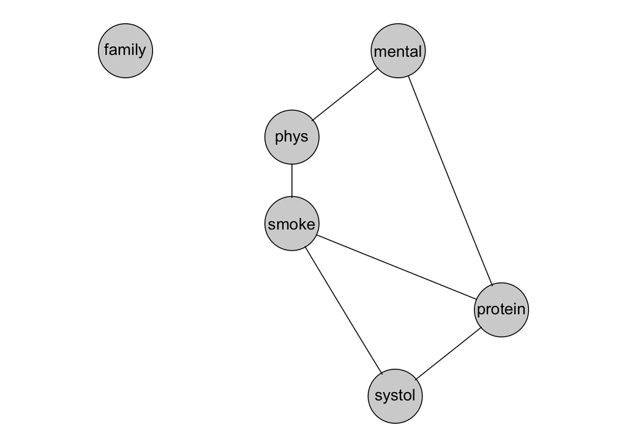

```r
plot(m_reinis)
```

```r
m_reinis
```

```
## Model: A dModel with 6 variables
##  graphical :  TRUE  decomposable : FALSE
##  -2logL    :       13349.28 mdim :   13 aic :     13375.28
##  ideviance :         780.94 idf  :    7 bic :     13447.01
##  deviance  :          63.01 df   :   50
## Notice: Table is sparse
##   Asymptotic chi2 distribution may be questionable.
```

Arriba podemos leer al AIC y BIC, adicionalmente realizamos gráficas de residuales:

```r
ajuste_1 <- data.frame(m_reinis$fit$fit)
ajuste_1$Freq_ajustada <- ajuste_1$Freq
ajuste_1$Freq <- NULL
dat_1 <- left_join(reinis_df, ajuste_1)
```

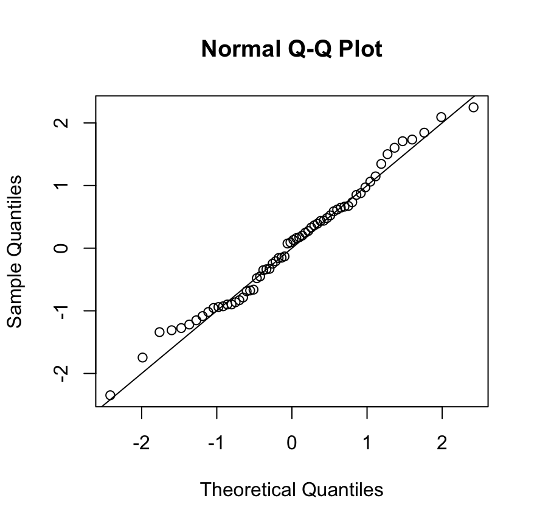

```r
residuales <- (dat_1$Freq - dat_1$Freq_ajustada)/sqrt(dat_1$Freq_ajustada)
qqnorm(residuales)
abline(a = 0, b = 1)
```

El ajuste todavía es razonable. Qué pasa si checamos algunas marginales:

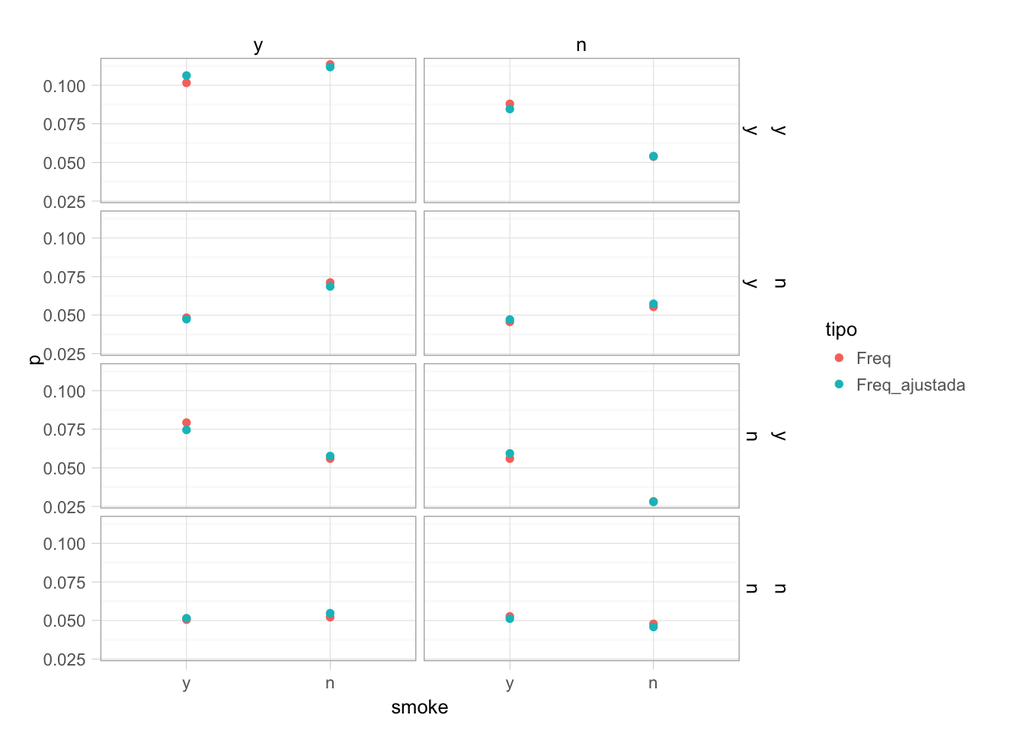

```r
dat_2 <- dat_1 %>%
  group_by(smoke, mental, protein, systol) %>%
  summarise(
    Freq = sum(Freq),
    Freq_ajustada = sum(Freq_ajustada)
    ) %>%
  gather(tipo, valor, Freq, Freq_ajustada)

ggplot(dat_2, aes(x = smoke, y = valor/sum(reinis), colour = tipo)) +
  facet_grid(mental + protein ~ systol) +
  geom_point() +
  labs(y = "p")
```

Podemos checar el cruce de family con mental

```r
# modelo
prop.table(apply(m_reinis$fit$fit, c('family','mental'), sum),1)
```

```
##       mental
## family    y    n
##      y 0.58 0.42
##      n 0.58 0.42
```

```r
#datos
prop.table(apply(reinis, c('family','mental'), sum), 1)
```

```
##       mental
## family    y    n
##      y 0.59 0.41
##      n 0.52 0.48
```

Es una diferencia relativamente chica, el error muestral es

```r
apply(reinis, c('family'), sum)
```

```
##    y    n
## 1581  260
```

```r
2 * sqrt(0.52 * (1 - 0.52) / 260)
```

```
## [1] 0.062
```

así que es marginalmente consistente con los datos

¿Qué pasa si penalizamos más fuerte?

```r
m_reinis_x <- stepwise(m_init, criterion = 'aic', k = 25, details = T,
                       direction = 'forward', type = 'unrestricted')
```

```
## STEPWISE:
##  criterion: aic ( k = 25 )
##  direction: forward
##  type     : unrestricted
##  search   : all
##  steps    : 1000
## . FORWARD: type=unrestricted search=all, criterion=aic(25.00), alpha=0.00
## . Initial model: is graphical=TRUE is decomposable=TRUE
##   change.AIC -660.9717 Edge added: mental phys
##   change.AIC   -2.4810 Edge added: smoke phys
```

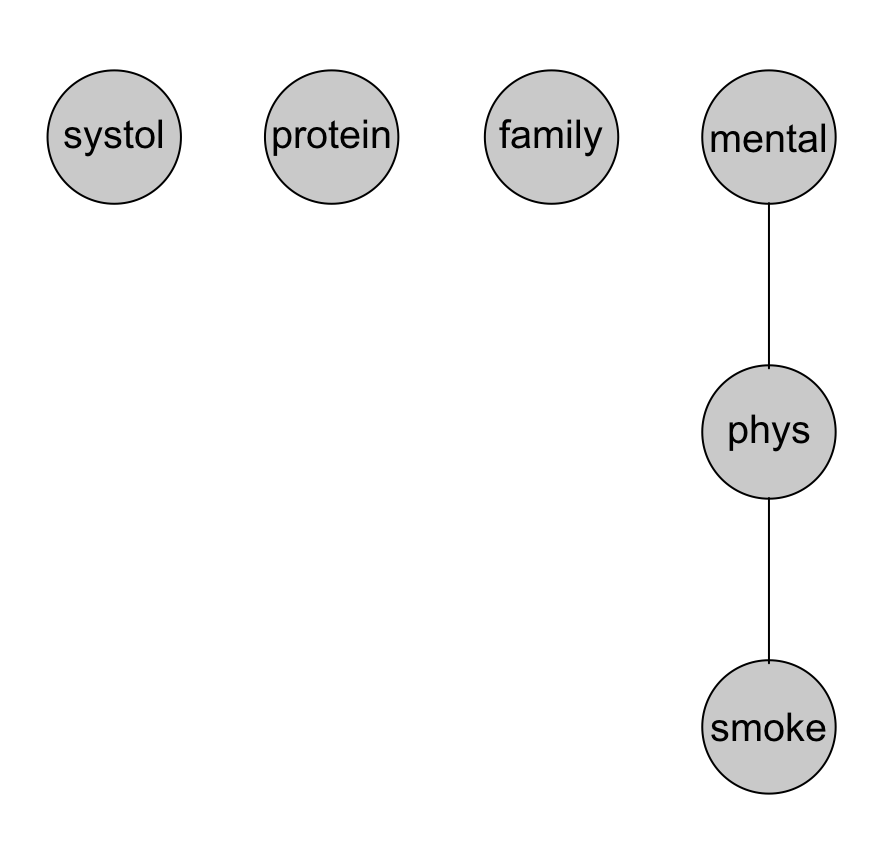

```r
plot(m_reinis_x)
```

```r
m_reinis_x
```

```
## Model: A dModel with 6 variables
##  graphical :  TRUE  decomposable :  TRUE
##  -2logL    :       13416.77 mdim :    8 aic :     13432.77
##  ideviance :         713.45 idf  :    2 bic :     13476.92
##  deviance  :         130.50 df   :   55
```

```r
ajuste_x <- data.frame(m_reinis_x$fit$fit)
ajuste_x$Freq_ajustada <- ajuste_x$Freq
ajuste_x$Freq <- NULL
dat_x <- left_join(reinis_df, ajuste_x)
```

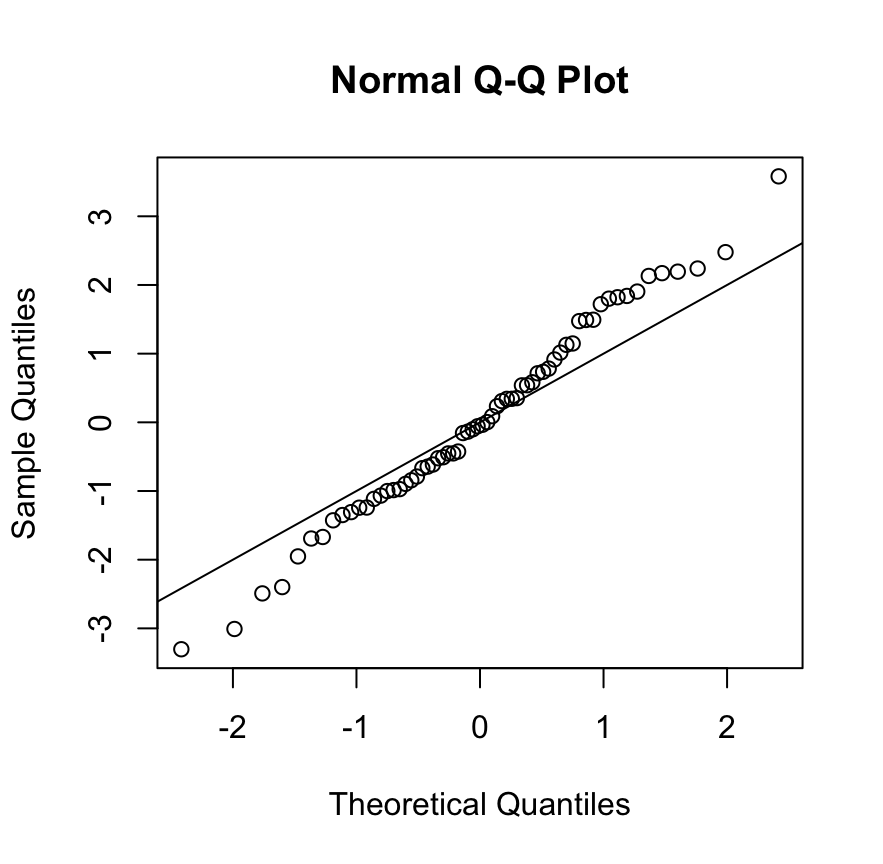

```r
residuales <- (dat_x$Freq - dat_x$Freq_ajustada) / sqrt(dat_x$Freq_ajustada)
qqnorm(residuales)
abline(a = 0, b = 1)
```

Notamos evidencia clara de desajuste.

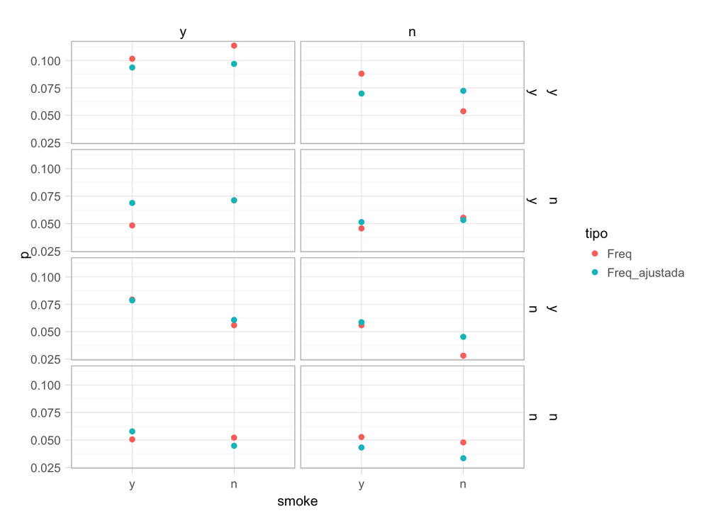

```r
dat_2x <- dat_x %>%
  group_by(smoke, mental, protein, systol) %>%
  summarise(
    Freq = sum(Freq),
    Freq_ajustada = sum(Freq_ajustada)
    ) %>%
  gather(tipo, valor, Freq, Freq_ajustada)

ggplot(dat_2x, aes(x = smoke, y = valor/sum(reinis), colour = tipo)) +
  facet_grid(mental + protein ~ systol) +
  geom_point() +
  labs(y = "p")
```

Podemos calcular intervalos para los datos para entender mejor si el modelo es consistente con los datos.

```r
dat_2x_p <- dat_2x %>%
  group_by(tipo) %>%    # agrupar por frecuencia de datos o ajustada
  mutate(Prop = valor / sum(valor)) %>%   # calcula proporción
  select(-valor) %>% # eliminar columna de frecuencias
  spread(tipo, Prop) %>% # separar en dos columnas las p's
  mutate(ee = sqrt(Freq * (1 - Freq) / sum(reinis)))  # calcular error estándar

ggplot(dat_2x_p, aes(x = smoke, y = Freq, ymin = Freq - 2 * ee,
  ymax = Freq + 2 * ee)) +
  geom_linerange() +
  facet_grid(mental + protein ~ systol) +
  geom_point() +
  geom_point(aes(y = Freq_ajustada), colour = 'red')
```

[output not shown]

Ahora podemos examinar el modelo anterior para entender distintos aspectos de los datos, usando como guía la representación gráfica.

```r
m_reinis <- stepwise(m_init, criterion='aic', k=15,
  details=T,  direction='forward', type='unrestricted')
```

```
## STEPWISE:
##  criterion: aic ( k = 15 )
##  direction: forward
##  type     : unrestricted
##  search   : all
##  steps    : 1000
## . FORWARD: type=unrestricted search=all, criterion=aic(15.00), alpha=0.00
## . Initial model: is graphical=TRUE is decomposable=TRUE
##   change.AIC -670.9717 Edge added: mental phys
##   change.AIC  -12.4810 Edge added: smoke phys
##   change.AIC   -2.9293 Edge added: protein mental
##   change.AIC  -25.4224 Edge added: smoke protein
##   change.AIC  -10.6185 Edge added: systol protein
##   change.AIC   -3.0833 Edge added: smoke systol
```

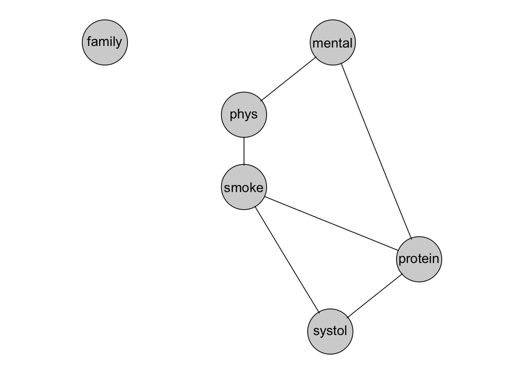

```r
plot(m_reinis)
```

```r
ajuste_1 <- (m_reinis$fit$fit)
```

Podemos hacer análisis condicional para una variable en términos de todos sus vecinos: las demas son condicionalmente independientes. Por ejemplo veamos condicional de systol dado smoke y protein

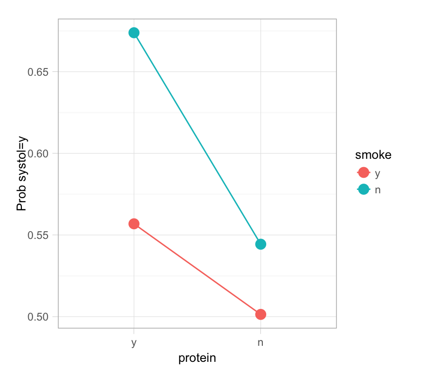

```r
tab_1 <- apply(ajuste_1, c('protein', 'systol', 'smoke'), sum)
tab_1p <- data.frame(as.table(prop.table(tab_1, margin = c(1, 3))))
tab_1p_sub <- filter(tab_1p, systol=='y')

ggplot(tab_1p_sub, aes(x = protein, y = Freq, colour = smoke, group = smoke)) +
  geom_point(size = 4) +
  geom_line() +
  ylab('Prob systol=y')
```